This Markdown explores 5 months data usage in Mega Bytes for 100K of Vodafone customers, subscribed to one of its rate plans. Our task is to predict whether a customer will exceed their average usage over the 5 months by 500 Mega Bytes in the coming month.

### Important to mention:

1. All the following models were trained using “neural network”" algorithm as it gave us the best performance compared to “randomForests”, “rpart”, “SVM”, “naivebayes” and “logistic regression”.
2. All models’ performance was evaluated by calculating the auc using “pRoc” R package, and cross validations.
3. Our approach was to produce many different models trained based on different attributes (splitting and joining the datasets accordingly) thus; having different submission files ensembling all files together at the end to get the highest accuracy- following this guide [link](http://mlwave.com/kaggle-ensembling-guide/):

First let’s load all **required libraries**:

```r
library("dplyr")
```

```r
library("ggplot2")
library('randomForest')
library('rpart')
library('dismo')
library('randomForest')
library('e1071')
library('adabag')
library('caret')
library('ipred')
library('C50')
library('stringi')
library('pROC')
library('nnet')
library('RWeka')
library('Boruta')
library('VIM')
library('DMwR')
library('mice')
library(gridExtra)
```

We started with loading the data:

```r
contract_ref <- read.csv("/Users/mayarelmohr/Documents/Semester10/DataScience/Vodafone2/StarBugs/VodafoneDataProject/contract_ref.csv")
daily_aggregate <- read.csv("/Users/mayarelmohr/Documents/Semester10/DataScience/Vodafone2/StarBugs/VodafoneDataProject/daily_aggregate.csv")
roaming_monthly <- read.csv("/Users/mayarelmohr/Documents/Semester10/DataScience/Vodafone2/StarBugs/VodafoneDataProject/roaming_monthly.csv")
calendar_ref <- read.csv("/Users/mayarelmohr/Documents/Semester10/DataScience/Vodafone2/StarBugs/VodafoneDataProject/calendar_ref.csv")
test <- read.csv("/Users/mayarelmohr/Documents/Semester10/DataScience/Vodafone2/StarBugs/VodafoneDataProject/test.csv")
train <- read.csv("/Users/mayarelmohr/Documents/Semester10/DataScience/Vodafone2/StarBugs/VodafoneDataProject/train.csv")
```

then, started **data exploration**, **cleaning** and **preparation**

### Variable Identification:

Identify Predictor (Input) and Target (Output) variables. Next, identify the data type and category of the variables.

```r
train %>% str()
```

```
## 'data.frame':    75422 obs. of  12 variables:
##  $ CONTRACT_KEY      : int  142404951 142404952 142405010 142405022 142405038 142405136 142405146 142405192 142405204 142405304 ...
##  $ X206_SESSION_COUNT: int  3581 962 466 875 728 25 1004 131 332 595 ...
##  $ X206_USAGE        : int  4405 4594 2520 4032 4119 4 471 783 2669 4733 ...
##  $ X207_SESSION_COUNT: int  3392 1341 467 675 352 21 1174 189 367 476 ...
##  $ X207_USAGE        : int  5598 2229 2141 3756 3235 4 398 1248 1718 2901 ...
##  $ X208_SESSION_COUNT: int  3337 1146 582 682 555 52 1172 193 775 334 ...
##  $ X208_USAGE        : int  5864 3980 1909 4283 2873 176 506 1139 2034 1028 ...
##  $ X209_SESSION_COUNT: int  3614 2210 583 579 102 278 1706 179 836 381 ...
##  $ X209_USAGE        : int  5541 2905 3735 3505 580 1084 514 1688 703 356 ...
##  $ X210_SESSION_COUNT: int  2999 2835 569 1000 489 338 371 168 844 338 ...
##  $ X210_USAGE        : int  3418 2432 5182 3553 1883 1060 270 840 625 238 ...
##  $ TARGET            : int  1 0 0 0 0 1 0 1 0 0 ...
```

```r
contract_ref %>% str()
```

```
## 'data.frame':    107743 obs. of  6 variables:
##  $ CONTRACT_KEY : int  142405022 142405691 142405932 142406618 142407103 142407264 142407568 142408488 142408809 142408854 ...
##  $ AGE          : int  30 39 45 50 28 31 44 26 44 34 ...
##  $ GENDER       : Factor w/ 8 levels "f","F","Female",..: 6 6 6 6 3 6 7 6 7 6 ...
##  $ RATE_PLAN    : Factor w/ 183 levels "2011 Bouquet 100",..: 181 99 89 181 99 141 74 138 74 138 ...
##  $ VALUE_SEGMENT: Factor w/ 7 levels "Core","High",..: 2 3 2 3 4 7 1 2 1 2 ...
##  $ HANDSET_NAME : Factor w/ 2058 levels "","Ace Group G005",..: 1807 211 1949 1152 115 788 1053 113 1591 1335 ...
```

```r
calendar_ref %>% str()
```

```
## 'data.frame':    183 obs. of  6 variables:
##  $ DATE_KEY    : int  6214 6215 6216 6217 6218 6219 6220 6221 6222 6223 ...
##  $ FULL_DATE   : Factor w/ 183 levels "2015-10-01","2015-10-02",..: 1 2 3 4 5 6 7 8 9 10 ...
##  $ DAY_NAME    : Factor w/ 7 levels "Friday","Monday",..: 5 1 3 4 2 6 7 5 1 3 ...
##  $ WEEKDAY_FLAG: Factor w/ 2 levels "N","Y": 2 1 1 2 2 2 2 2 1 1 ...
##  $ MONTH_KEY   : int  206 206 206 206 206 206 206 206 206 206 ...
##  $ MONTH_NAME  : Factor w/ 6 levels "December","February",..: 6 6 6 6 6 6 6 6 6 6 ...
```

```r
roaming_monthly %>% str()
```

```
## 'data.frame':    3946 obs. of  4 variables:
##  $ CONTRACT_KEY  : int  142405434 142405434 142405460 142405509 142406275 142406275 142406275 142406275 142407264 142407681 ...
##  $ CALL_MONTH_KEY: int  206 207 209 209 206 208 209 210 206 209 ...
##  $ USAGE         : int  74 110 9 4 22 477 18 257 155 10 ...
##  $ SESSION_COUNT : int  190 312 33 6 55 709 64 409 90 5 ...
```

```r
daily_aggregate %>% str()
```

```
## 'data.frame':    4985457 obs. of  6 variables:
##  $ CONTRACT_KEY     : int  146706891 143460816 149913204 142784291 143769763 143769763 146706891 152485115 149896000 149896000 ...
##  $ CALL_DATE_KEY    : int  6343 6357 6343 6337 6340 6339 6341 6347 6344 6344 ...
##  $ CELL_KEY         : int  6393501 6393501 6393501 6393501 6393501 6393501 6393501 6393501 6393501 6393501 ...
##  $ ROAMING_FLAG     : Factor w/ 2 levels "LOCAL","ROAMING": 1 1 1 1 1 1 1 1 1 1 ...
##  $ TOTAL_CONSUMPTION: num  0 7929856 0 1703936 131072 ...
##  $ NO_OF_SESSIONS   : int  1 2 1 1 1 2 4 1 3 1 ...
```

```r
test %>% str()
```

```
## 'data.frame':    32321 obs. of  11 variables:
##  $ CONTRACT_KEY      : int  142404960 142405123 142405133 142405364 142405389 142405406 142405611 142405691 142405736 142405746 ...
##  $ X206_SESSION_COUNT: int  2319 896 525 2810 31 154 184 237 2002 49 ...
##  $ X206_USAGE        : int  5543 5388 794 928 255 6163 50 348 7169 15 ...
##  $ X207_SESSION_COUNT: int  2526 1084 598 2701 40 19 43 375 2003 12 ...
##  $ X207_USAGE        : int  4892 5182 752 599 450 1328 110 862 5188 17 ...
##  $ X208_SESSION_COUNT: int  2420 1475 516 2886 36 226 30 240 2315 4 ...
##  $ X208_USAGE        : int  5393 4161 512 532 891 2249 170 1289 4146 1 ...
##  $ X209_SESSION_COUNT: int  2735 1585 448 3433 30 98 91 227 2431 8 ...
##  $ X209_USAGE        : int  3214 1670 482 1015 596 5366 54 41 4883 3 ...
##  $ X210_SESSION_COUNT: int  2392 1380 800 3319 32 157 253 254 2875 53 ...
##  $ X210_USAGE        : int  5320 1864 770 1518 834 3761 92 5 14565 74 ...
```

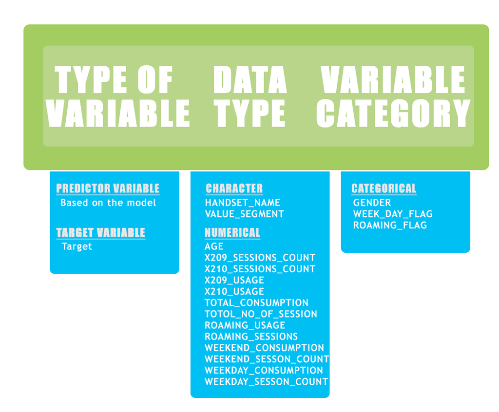

### Missing Values Treatment:

First we inspect and plot the missing data in table **contract_ref**:

#### 1. VALUE_SEGMENT

```r
contract_ref$VALUE_SEGMENT[contract_ref$VALUE_SEGMENT == "N/A"] <- NA
md.pattern(contract_ref)
```

```
##       CONTRACT_KEY AGE GENDER RATE_PLAN HANDSET_NAME VALUE_SEGMENT
## 99568            1   1      1         1            1             1    0
##  8175            1   1      1         1            1             0    1
##                  0   0      0         0            0          8175 8175
```

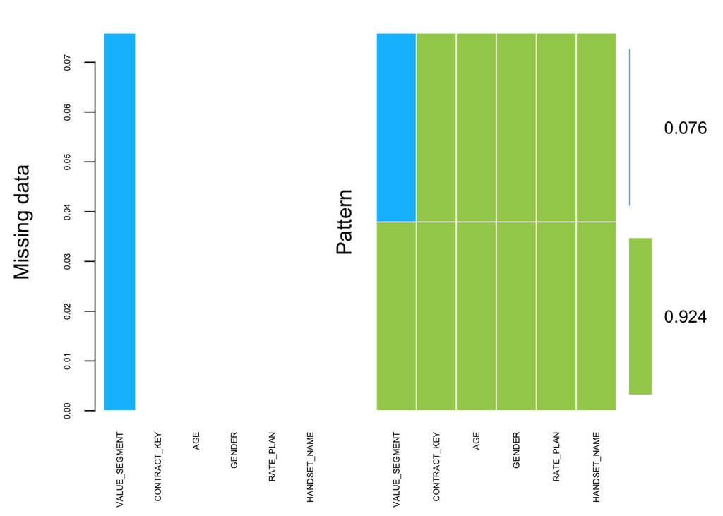

```
##
##  Variables sorted by number of missings:
##       Variable    Count
##  VALUE_SEGMENT 0.075875
##   CONTRACT_KEY 0.000000
##            AGE 0.000000
##         GENDER 0.000000
##      RATE_PLAN 0.000000
##   HANDSET_NAME 0.000000
```

```r
mice_plot <- aggr(contract_ref, col=c('darkolivegreen3','deepskyblue1'), alpha = 0.4, numbers=TRUE, border = FALSE, sortVars=TRUE, labels=names(contract_ref), cex.axis=.5, gap=2, ylab=c("Missing data","Pattern"))
```

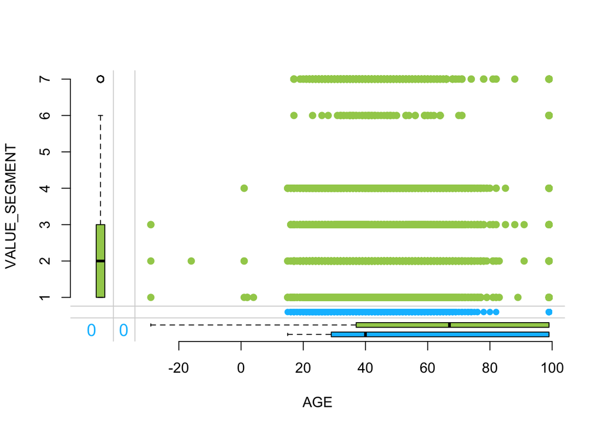

```r
marginplot(contract_ref[, c("AGE", "VALUE_SEGMENT")], col = c('darkolivegreen3','deepskyblue1'), delimiter = NULL, cex.numbers = 1.2, pch = 19, frame.plot = FALSE)
```

Imputing the NA’s of the VALUE_SEGMENT in table contract_ref, using KNN Imputation where the missing values of an attribute are imputed using the given number of attributes that are most similar to the attribute whose values are missing:

```r
contract_ref_imputed <- knnImputation(contract_ref)
```

#### 2.GENDER

First we change the gender values to Male, Female, Not enetered, instead of having f, F, m, M, Unknown.

```r
levels(contract_ref_imputed$GENDER)[levels(contract_ref_imputed$GENDER) == "F"] <- "Female"
levels(contract_ref_imputed$GENDER)[levels(contract_ref_imputed$GENDER) == "f"] <- "Female"
levels(contract_ref_imputed$GENDER)[levels(contract_ref_imputed$GENDER) == "m"] <- "Male"
levels(contract_ref_imputed$GENDER)[levels(contract_ref_imputed$GENDER) == "M"] <- "Male"
levels(contract_ref_imputed$GENDER)[levels(contract_ref_imputed$GENDER) == "Unknown"] <- "Not Entered"
```

Proceed plotting the GENDER distribution:

```r
train_contract_ref_imputed <- inner_join(train, contract_ref_imputed, BY = "CONTRACT_KEY")
```

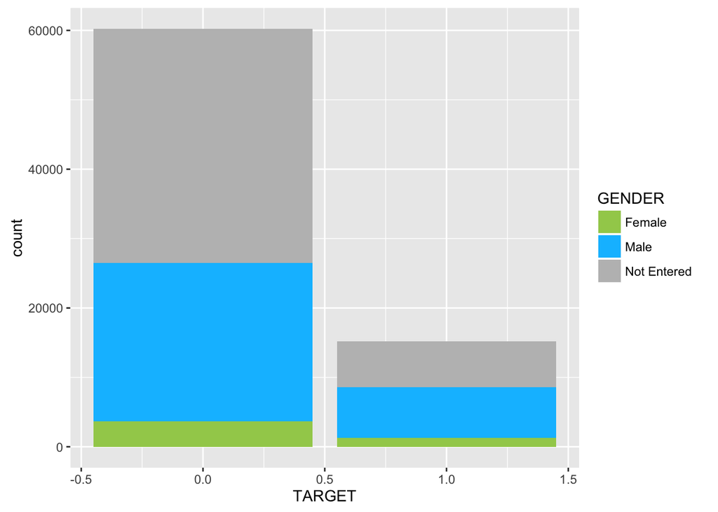

```r
qplot(TARGET, data=train_contract_ref_imputed, fill=GENDER, geom="bar") + scale_fill_manual(values=c("darkolivegreen3", "deepskyblue1", "gray"))
```

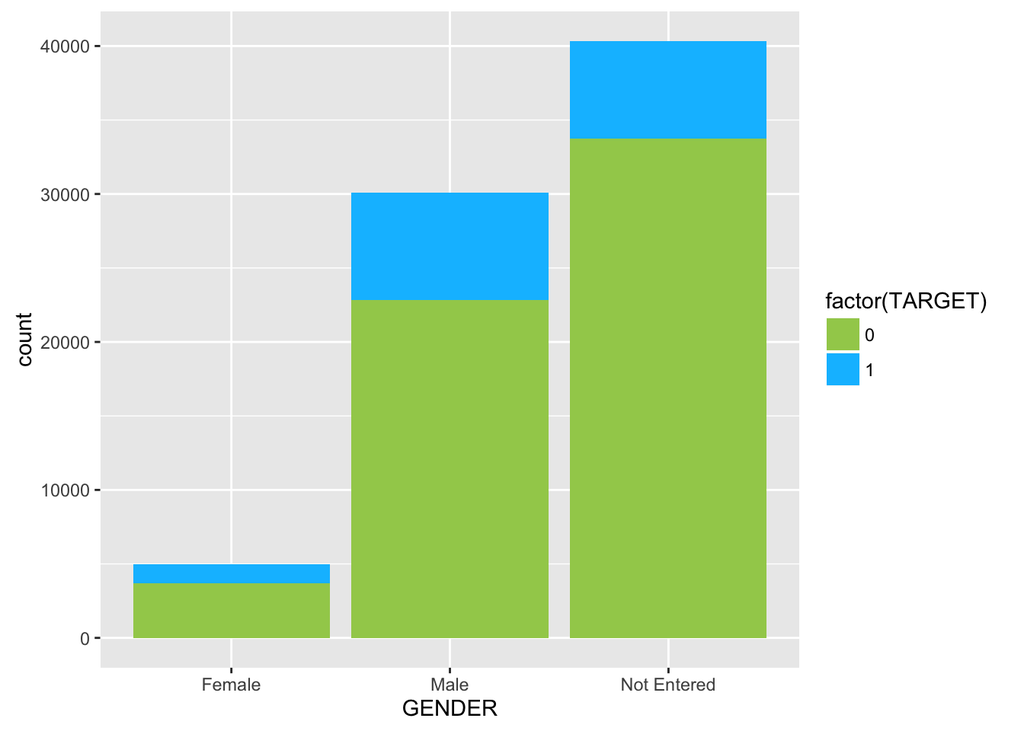

```r
qplot(GENDER, data=train_contract_ref_imputed, fill=factor(TARGET))  + scale_fill_manual(values=c("darkolivegreen3", "deepskyblue1"))
```

#### 3. AGE

The age has some -ve values where we assumed its a wrong entry, and a alot of 99 values, which corresponds to the gender of Not Entered where we assumed that all the 99 values are NA’s.

We performed Mean Imputation according to the corresponding value segment, where we grouped the age into two groups

1- Group with age < 16, where it’s illegal to sign a contract from a Telcom agency

2- Group with age = 99

```r
contract_ref_filtered = filter(contract_ref_imputed, as.numeric(contract_ref_imputed$AGE) >= 16)
contract_ref_filtered = filter(contract_ref_imputed, as.numeric(contract_ref_imputed$AGE) <= 95)


contract_ref_unfiltered = anti_join(contract_ref_imputed, contract_ref_filtered, by = "CONTRACT_KEY")


age_of_Core_Segment <- data.frame( contract_ref_filtered$AGE[contract_ref_filtered$VALUE_SEGMENT == 'Core'])
p1 <- ggplot() + geom_bar(data = age_of_Core_Segment, aes(x=age_of_Core_Segment$contract_ref_filtered.AGE.contract_ref_filtered.VALUE_SEGMENT....), fill = "darkolivegreen3" )  + ggtitle("Age of Core Value segment") + xlab("Age")

mean_core <- mean(as.numeric(age_of_Core_Segment$contract_ref_filtered.AGE.contract_ref_filtered.VALUE_SEGMENT....), na.rm= TRUE)

age_of_Med_low <- data.frame( contract_ref_filtered$AGE[contract_ref_filtered$VALUE_SEGMENT == 'Med-Low'])
p2 <-ggplot()+  geom_histogram(data = age_of_Med_low, aes(x=age_of_Med_low$contract_ref_filtered.AGE.contract_ref_filtered.VALUE_SEGMENT....), fill = "deepskyblue1") + ggtitle("Age of Med Low Value segment") + xlab("Age")



mean_med_low <- mean(as.numeric(age_of_Med_low$contract_ref_filtered.AGE.contract_ref_filtered.VALUE_SEGMENT....), na.rm= TRUE)

age_of_High_Segment <- data.frame( contract_ref_filtered$AGE[contract_ref_filtered$VALUE_SEGMENT == 'High'])
p3 <- ggplot() + geom_bar(data = age_of_High_Segment, aes(x=age_of_High_Segment$contract_ref_filtered.AGE.contract_ref_filtered.VALUE_SEGMENT....),  fill = "deepskyblue1")  + ggtitle("Age of High Value segment") + xlab("Age")


mean_high <- mean(as.numeric(age_of_High_Segment$contract_ref_filtered.AGE.contract_ref_filtered.VALUE_SEGMENT....), na.rm= TRUE)

age_of_Med_High_Segment <- data.frame( contract_ref_filtered$AGE[contract_ref_filtered$VALUE_SEGMENT == 'Med-High'])
p4 <- ggplot() + geom_bar(data = age_of_Med_High_Segment, aes(x=age_of_Med_High_Segment$contract_ref_filtered.AGE.contract_ref_filtered.VALUE_SEGMENT....),  fill = "darkolivegreen3")  + ggtitle("Age of Mid-High Value segment") + xlab("Age")
mean_med_high <- mean(as.numeric(age_of_Med_High_Segment$contract_ref_filtered.AGE.contract_ref_filtered.VALUE_SEGMENT....), na.rm= TRUE)


age_of_premium <- data.frame( contract_ref_filtered$AGE[contract_ref_filtered$VALUE_SEGMENT == 'Premium'])
p5 <- ggplot() + geom_bar(data = age_of_premium, aes(x=age_of_premium$contract_ref_filtered.AGE.contract_ref_filtered.VALUE_SEGMENT....),,  fill = "deepskyblue1")  + ggtitle("Age of premium Value segment") + xlab("Age")
mean_premium <- mean(as.numeric(age_of_premium$contract_ref_filtered.AGE.contract_ref_filtered.VALUE_SEGMENT....), na.rm= TRUE)



age_of_platinum <- data.frame( contract_ref_filtered$AGE[contract_ref_filtered$VALUE_SEGMENT == 'Platinum'])
p6 <- ggplot() + geom_bar(data = age_of_platinum, aes(x=age_of_platinum$contract_ref_filtered.AGE.contract_ref_filtered.VALUE_SEGMENT....),  fill = "darkolivegreen3")  + ggtitle("Age of platinum Value segment") + xlab("Age")
mean_platinum <- mean(as.numeric(age_of_platinum$contract_ref_filtered.AGE.contract_ref_filtered.VALUE_SEGMENT....), na.rm = TRUE)

contract_ref_unfiltered$AGE[contract_ref_unfiltered$VALUE_SEGMENT ==as.character("Core") ] = as.integer(mean_core)
contract_ref_unfiltered$AGE[contract_ref_unfiltered$VALUE_SEGMENT ==as.character("High") ] = as.integer(mean_high)
contract_ref_unfiltered$AGE[contract_ref_unfiltered$VALUE_SEGMENT ==as.character("Med-Low") ] = as.integer(mean_med_low)
contract_ref_unfiltered$AGE[contract_ref_unfiltered$VALUE_SEGMENT ==as.character("Med-High") ] = as.integer(mean_med_high)
contract_ref_unfiltered$AGE[contract_ref_unfiltered$VALUE_SEGMENT ==as.character("Premium") ] = as.integer(mean_premium)
contract_ref_unfiltered$AGE[contract_ref_unfiltered$VALUE_SEGMENT ==as.character("Platinum") ] = as.integer(mean_platinum)



contract_ref_new = bind_rows(contract_ref_unfiltered, contract_ref_filtered)
```

Value segments of ‘Med-Low’ and ‘Med-High’ were both combined to a ‘Medium’ value segment

```r
levels(contract_ref_new$VALUE_SEGMENT)[contract_ref_new$VALUE_SEGMENT == "Med-High"] = "Medium"
levels(contract_ref_new$VALUE_SEGMENT)[contract_ref_new$VALUE_SEGMENT == "Med-Low"] = "Medium"
contract_ref_new$VALUE_SEGMENT[contract_ref_new$VALUE_SEGMENT == "Med-High"] = "Medium"
contract_ref_new$VALUE_SEGMENT[contract_ref_new$VALUE_SEGMENT == "Med-Low"] = "Medium"
```

Below is a graph for age distribution within each value segment

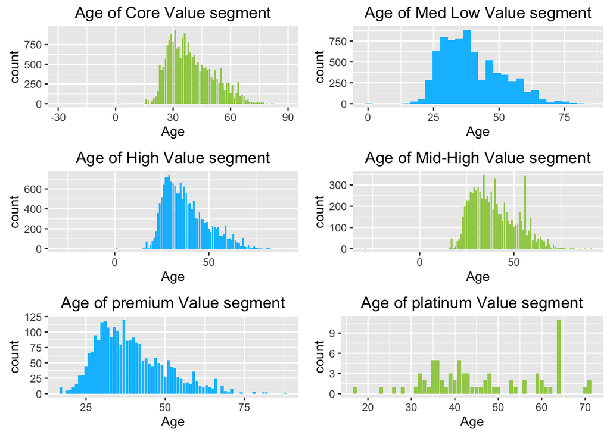

```r
grid.arrange(p1,p2,p3,p4,p5,p6, ncol = 2, nrow = 3)
```

#### 4.HANDSET NAME

Handset names were grouped by types to reduce their levels according to the brand where we assumed that the handset would affect the consumption especially the internet usage. We googled and researched the mobiles of unfamilar brands to group them together, also we figured that some of the handsets resembled companies and agencies thus we grouped them together to a new level called “Agency”

They were clustered into less levels Below is a graph showing the occurence of value segments within the given contract _ref

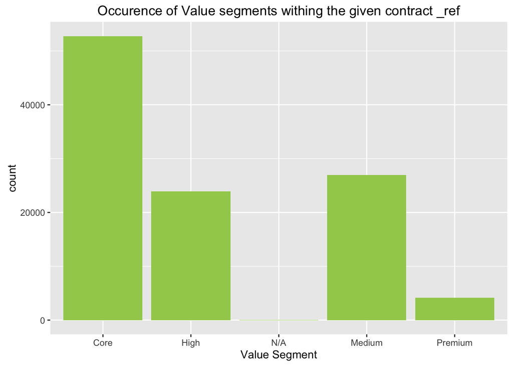

```r
ggplot() + geom_bar(data = contract_ref_new, aes(x=VALUE_SEGMENT),  fill = "darkolivegreen3")  + ggtitle("Occurence of Value segments withing the given contract _ref") + xlab("Value Segment")
```

```r
contract_ref_new$HANDSET_NAME <- sub(".*Samsung.*", "Samsung", contract_ref_new$HANDSET_NAME, ignore.case = TRUE)
contract_ref_new$HANDSET_NAME <- sub(".*Sony.*", "Sony", contract_ref_new$HANDSET_NAME, ignore.case = TRUE)
contract_ref_new$HANDSET_NAME <- sub(".*Apple.*", "Apple", contract_ref_new$HANDSET_NAME, ignore.case = TRUE)
contract_ref_new$HANDSET_NAME <- sub(".*GoogleNexus.*", "GoogleNexus", contract_ref_new$HANDSET_NAME, ignore.case = TRUE)
contract_ref_new$HANDSET_NAME <- sub(".*BlackBerry.*", "BlackBerry", contract_ref_new$HANDSET_NAME, ignore.case = TRUE)
contract_ref_new$HANDSET_NAME <- sub(".*Asus.*", "Asus", contract_ref_new$HANDSET_NAME, ignore.case = TRUE)
contract_ref_new$HANDSET_NAME <- sub(".*Vodafone.*", "Vodafone", contract_ref_new$HANDSET_NAME, ignore.case = TRUE)
contract_ref_new$HANDSET_NAME <- sub(".*HTC.*", "HTC", contract_ref_new$HANDSET_NAME, ignore.case = TRUE)
contract_ref_new$HANDSET_NAME <- sub(".*Lenovo.*", "Lenovo", contract_ref_new$HANDSET_NAME, ignore.case = TRUE)
contract_ref_new$HANDSET_NAME <- sub(".*Simcom.*", "Simcom", contract_ref_new$HANDSET_NAME, ignore.case = TRUE)
contract_ref_new$HANDSET_NAME <- sub(".*Microsoft.*", "Microsoft", contract_ref_new$HANDSET_NAME, ignore.case = TRUE)
contract_ref_new$HANDSET_NAME <- sub(".*Huawei.*", "Huawei", contract_ref_new$HANDSET_NAME, ignore.case = TRUE)
contract_ref_new$HANDSET_NAME <- sub(".*Alcatel.*", "Alcatel", contract_ref_new$HANDSET_NAME, ignore.case = TRUE)
contract_ref_new$HANDSET_NAME <- sub(".*Nokia.*", "Nokia", contract_ref_new$HANDSET_NAME, ignore.case = TRUE)
contract_ref_new$HANDSET_NAME <- sub(".*Sico.*", "Sico", contract_ref_new$HANDSET_NAME, ignore.case = TRUE)
contract_ref_new$HANDSET_NAME <- sub(".*Beryl.*", "Beryl", contract_ref_new$HANDSET_NAME, ignore.case = TRUE)
contract_ref_new$HANDSET_NAME <- sub(".*TP-Link.*", "TP-Link", contract_ref_new$HANDSET_NAME, ignore.case = TRUE)
contract_ref_new$HANDSET_NAME <- sub(".*Fibocom.*", "Fibocom", contract_ref_new$HANDSET_NAME, ignore.case = TRUE)
contract_ref_new$HANDSET_NAME <- sub(".*Verifone.*", "Verifone", contract_ref_new$HANDSET_NAME, ignore.case = TRUE)
contract_ref_new$HANDSET_NAME <- sub(".*Cinterion.*", "Cinterion", contract_ref_new$HANDSET_NAME, ignore.case = TRUE)
contract_ref_new$HANDSET_NAME <- sub(".*Siemens.*", "Siemens", contract_ref_new$HANDSET_NAME, ignore.case = TRUE)
contract_ref_new$HANDSET_NAME <- sub(".*G-tide.*", "G-tide", contract_ref_new$HANDSET_NAME, ignore.case = TRUE)
contract_ref_new$HANDSET_NAME <- sub(".*Cisco.*", "Cisco", contract_ref_new$HANDSET_NAME, ignore.case = TRUE)
contract_ref_new$HANDSET_NAME <- sub(".*Quectel.*", "QuectelWirelessSolutions", contract_ref_new$HANDSET_NAME, ignore.case = TRUE)
contract_ref_new$HANDSET_NAME <- sub(".*Assure.*", "Assure", contract_ref_new$HANDSET_NAME, ignore.case = TRUE)
contract_ref_new$HANDSET_NAME <- sub(".*Arab.*", "Agency", contract_ref_new$HANDSET_NAME, ignore.case = TRUE)
contract_ref_new$HANDSET_NAME <- sub(".*tele.*", "Agency", contract_ref_new$HANDSET_NAME, ignore.case = TRUE)
contract_ref_new$HANDSET_NAME <- sub(".*Tele.*", "Agency", contract_ref_new$HANDSET_NAME, ignore.case = TRUE)
contract_ref_new$HANDSET_NAME <- sub(".*ZTE.*", "ZTE", contract_ref_new$HANDSET_NAME, ignore.case = TRUE)
contract_ref_new$HANDSET_NAME <- sub(".*ACER.*", "ACER", contract_ref_new$HANDSET_NAME, ignore.case = TRUE)
contract_ref_new$HANDSET_NAME <- sub(".*Ace.*", "Agency", contract_ref_new$HANDSET_NAME, ignore.case = TRUE)
contract_ref_new$HANDSET_NAME <- sub(".*ZTS.*", "Agency", contract_ref_new$HANDSET_NAME, ignore.case = TRUE)
contract_ref_new$HANDSET_NAME <- sub(".*ZTC.*", "ZTC", contract_ref_new$HANDSET_NAME, ignore.case = TRUE)
contract_ref_new$HANDSET_NAME <- sub(".*Express.*", "Agency", contract_ref_new$HANDSET_NAME, ignore.case = TRUE)
contract_ref_new$HANDSET_NAME <- sub(".*Technology.*", "Agency", contract_ref_new$HANDSET_NAME, ignore.case = TRUE)
contract_ref_new$HANDSET_NAME <- sub(".*technology.*", "Agency", contract_ref_new$HANDSET_NAME, ignore.case = TRUE)
contract_ref_new$HANDSET_NAME <- sub(".*tech.*", "Agency", contract_ref_new$HANDSET_NAME, ignore.case = TRUE)
contract_ref_new$HANDSET_NAME <- sub(".*tec.*", "Agency", contract_ref_new$HANDSET_NAME, ignore.case = TRUE)
contract_ref_new$HANDSET_NAME <- sub(".*Xiaomi.*", "Agency", contract_ref_new$HANDSET_NAME, ignore.case = TRUE)
contract_ref_new$HANDSET_NAME <- sub(".*Wiko.*", "Wiko", contract_ref_new$HANDSET_NAME, ignore.case = TRUE)
contract_ref_new$HANDSET_NAME <- sub(".*Souq.*", "Agency", contract_ref_new$HANDSET_NAME, ignore.case = TRUE)
contract_ref_new$HANDSET_NAME <- sub(".*Sierra.*", "Agency", contract_ref_new$HANDSET_NAME, ignore.case = TRUE)
contract_ref_new$HANDSET_NAME <- sub(".*Motorola.*", "Motorola", contract_ref_new$HANDSET_NAME, ignore.case = TRUE)
contract_ref_new$HANDSET_NAME <- sub(".*Hisense.*", "Agency", contract_ref_new$HANDSET_NAME, ignore.case = TRUE)
contract_ref_new$HANDSET_NAME <- sub(".*Trading.*", "Agency", contract_ref_new$HANDSET_NAME, ignore.case = TRUE)
contract_ref_new$HANDSET_NAME <- sub(".*Telit.*", "Agency", contract_ref_new$HANDSET_NAME, ignore.case = TRUE)
contract_ref_new$HANDSET_NAME <- sub(".*Lulu.*", "Lulu", contract_ref_new$HANDSET_NAME, ignore.case = TRUE)
contract_ref_new$HANDSET_NAME <- sub(".*LG.*", "LG", contract_ref_new$HANDSET_NAME, ignore.case = TRUE)
contract_ref_new$HANDSET_NAME <- sub(".*HP.*", "HP", contract_ref_new$HANDSET_NAME, ignore.case = TRUE)
contract_ref_new$HANDSET_NAME <- sub(".*Group.*", "Group", contract_ref_new$HANDSET_NAME, ignore.case = TRUE)
contract_ref_new$HANDSET_NAME <- sub(".*Goldgoal.*", "Agency", contract_ref_new$HANDSET_NAME, ignore.case = TRUE)
contract_ref_new$HANDSET_NAME <- sub(".*Goldgoal .*", "Agency", contract_ref_new$HANDSET_NAME, ignore.case = TRUE)
contract_ref_new$HANDSET_NAME <- sub(".* Goldgoal .*", "Agency", contract_ref_new$HANDSET_NAME, ignore.case = TRUE)
contract_ref_new$HANDSET_NAME <- sub(".*Import.*", "Agency", contract_ref_new$HANDSET_NAME, ignore.case = TRUE)
contract_ref_new$HANDSET_NAME <- sub(".*ARCHOS.*", "ARCHOS", contract_ref_new$HANDSET_NAME, ignore.case = TRUE)
contract_ref_new$HANDSET_NAME <- sub(".* Coolpad.*", " Coolpad", contract_ref_new$HANDSET_NAME, ignore.case = TRUE)
contract_ref_new$HANDSET_NAME <- sub(".*Oppo.*", "Oppo", contract_ref_new$HANDSET_NAME, ignore.case = TRUE)
contract_ref_new$HANDSET_NAME <- sub(".*Sharp.*", "Sharp", contract_ref_new$HANDSET_NAME, ignore.case = TRUE)
contract_ref_new$HANDSET_NAME <- sub(".*Panasonic.*", "Panasonic", contract_ref_new$HANDSET_NAME, ignore.case = TRUE)
contract_ref_new$HANDSET_NAME <- sub(".* BLU.*", "BLU", contract_ref_new$HANDSET_NAME, ignore.case = TRUE)
contract_ref_new$HANDSET_NAME <- sub(".*BLU.*", "BLU", contract_ref_new$HANDSET_NAME, ignore.case = TRUE)
contract_ref_new$HANDSET_NAME <- sub(".*Infinix.*", "Infinix", contract_ref_new$HANDSET_NAME, ignore.case = TRUE)
contract_ref_new$HANDSET_NAME <- sub(".*Shenzhen.*", "Shenzhen", contract_ref_new$HANDSET_NAME, ignore.case = TRUE)
contract_ref_new$HANDSET_NAME <- sub(".*Teltonika.*", "Teltonika", contract_ref_new$HANDSET_NAME, ignore.case = TRUE)
contract_ref_new$HANDSET_NAME <- sub(".*Sagem.*", "Agency", contract_ref_new$HANDSET_NAME, ignore.case = TRUE)
contract_ref_new$HANDSET_NAME <- sub(".*Fly Mobiles.*", "Fly Mobiles", contract_ref_new$HANDSET_NAME, ignore.case = TRUE)
contract_ref_new$HANDSET_NAME <- sub(".*K-Touch.*", "K-Touch", contract_ref_new$HANDSET_NAME, ignore.case = TRUE)
contract_ref_new$HANDSET_NAME <- sub(".*OnePlus.*", "OnePlus", contract_ref_new$HANDSET_NAME, ignore.case = TRUE)
contract_ref_new$HANDSET_NAME <- as.factor(contract_ref_new$HANDSET_NAME)
```

After doing, some feature engineering, we created a new instance of traing set that has the usage and session counts of the last two month, in addition to the total of usage and sessions of the first three months, with AUC score = 0.667

```r
train_9_10 <- train

train_9_10  <-  cbind(TOTAL_USAGE = (train$X206_USAGE + train$X207_USAGE  +train$X208_USAGE ), train_9_10)

train_9_10 <-  cbind(TOTAL_SESSIONS = (train$X206_SESSION_COUNT + train$X207_SESSION_COUNT  +train$X208_SESSION_COUNT ), train_9_10)

train_9_10 <- dplyr::select(train_9_10, -c( X206_SESSION_COUNT, X207_SESSION_COUNT, X208_SESSION_COUNT,
 X206_USAGE, X207_USAGE, X208_USAGE ))
nn <- make_Weka_classifier("weka/classifiers/functions/MultilayerPerceptron")
model <- nn(as.factor(TARGET)~. -CONTRACT_KEY, data= train_9_10)
predictedFold <- data.frame(predict(model,  train_9_10[1:7], type = "class"))
auc(as.numeric(train_9_10$TARGET), as.numeric(predictedFold$predict.model..train_9_10.1.7...type....class..))
```

```
## Area under the curve: 0.667
```

Next, we inspect and plot the **daily_aggregate** to get some sights about the ROAMING and LOCAL: Having all the roaming and local usage and number of sessions prepared in extrernal .csv file, we load them directly, then join the tables accordingly:

```r
local_consumption <- read.csv("local_consumption.csv")
roaming_consumption <- read.csv("roaming_consumption.csv")
local_sessions_count <- read.csv("local_sessions_count.csv")
roaming_sessions_count <- read.csv("roaming_sessions_count.csv")
```

```r
train_roaming <- dplyr::left_join(train_9_10, local_sessions_count, BY = "CONTRACT_KEY")
train_roaming <- dplyr::left_join(train_roaming, local_consumption, BY = "CONTRACT_KEY")
train_roaming <- dplyr::left_join(train_roaming, roaming_consumption, BY = "CONTRACT_KEY")
train_roaming <- dplyr::left_join(train_roaming, roaming_sessions_count, BY = "CONTRACT_KEY")
#levels(train_roaming$ROAMING_USAGE)[is.na(train_roaming$ROAMING_USAGE)] = 0
train_roaming$ROAMING_USAGE[is.na(train_roaming$ROAMING_USAGE)] = 0
#levels(train_roaming$LOCAL_USAGE)[is.na(train_roaming$LOCAL_USAGE)] = 0
train_roaming$LOCAL_USAGE[is.na(train_roaming$LOCAL_USAGE)] = 0
#levels(train_roaming$LOCAL_SESSIONS_COUNT)[is.na(train_roaming$LOCAL_SESSIONS_COUNT)] = 0
train_roaming$LOCAL_SESSIONS_COUNT[is.na(train_roaming$LOCAL_SESSIONS_COUNT)] = 0
#levels(train_roaming$ROAMING_SESSIONS_COUNT)[is.na(train_roaming$ROAMING_SESSIONS_COUNT)] = 0
train_roaming$ROAMING_SESSIONS_COUNT[is.na(train_roaming$ROAMING_SESSIONS_COUNT)] = 0
train_roaming$LOCAL_USAGE <- train_roaming$LOCAL_USAGE/(1024*1024)
train_roaming$LOCAL_USAGE <- as.integer(train_roaming$LOCAL_USAGE)


train_roaming$ROAMING_USAGE <- train_roaming$ROAMING_USAGE/(1024*1024)
train_roaming$ROAMING_USAGE <- as.integer(train_roaming$ROAMING_USAGE)
```

```r
train_roaming <- train_roaming[c(1,2,3,4,5,6,7,9,10,11,12,8)]

model <- nn(as.factor(TARGET)~. -CONTRACT_KEY, data= train_roaming)
predictedFold <- data.frame(predict(model,  train_roaming[1:11], type = "class"))
auc(as.numeric(train_roaming$TARGET), as.numeric(predictedFold$predict.model..train_roaming.1.11...type....class..))
```

```
## Area under the curve: 0.5526
```

Having the ROAMING_CONSUMPTION, LOCAL_CONSUMPTION prepared beside the previously prepared dataset attributes, we train the datasets having different models and different submission files:

All models trained using neural networks, below each submission file and it’s corresponding model calculated auc score:

[output not shown]

```r
contract_ref_train <- train_roaming
contract_ref_train <- inner_join(contract_ref_train, contract_ref_new, by = "CONTRACT_KEY")
contract_ref_train <- dplyr::select(contract_ref_train, -c(RATE_PLAN, X209_SESSION_COUNT,
LOCAL_USAGE,
LOCAL_SESSIONS_COUNT, GENDER, VALUE_SEGMENT, HANDSET_NAME
 ))

contract_ref_train <- contract_ref_train[c(1,2,3,4,5,6,7,8,10,9)]

model <- nn(as.factor(TARGET)~. - CONTRACT_KEY, data= contract_ref_train)
predictedFold <- data.frame(predict(model,  contract_ref_train[1:9], type = "class"))
auc(as.numeric(contract_ref_train$TARGET), as.numeric(predictedFold$predict.model..contract_ref_train.1.9...type....class..))
```

```
## Area under the curve: 0.6775
```

```r
##GENDER

contract_ref_train <- train_roaming
contract_ref_train <- inner_join(contract_ref_train, contract_ref_new, by = "CONTRACT_KEY")
contract_ref_train <- dplyr::select(contract_ref_train, -c(RATE_PLAN, X209_SESSION_COUNT,
LOCAL_USAGE,
LOCAL_SESSIONS_COUNT, AGE, VALUE_SEGMENT, HANDSET_NAME
 ))

contract_ref_train <- contract_ref_train[c(1,2,3,4,5,6,7,8,10,9)]

model <- nn(as.factor(TARGET)~. - CONTRACT_KEY, data= contract_ref_train)
predictedFold <- data.frame(predict(model,  contract_ref_train[1:9], type = "class"))
auc(as.numeric(contract_ref_train$TARGET), as.numeric(predictedFold$predict.model..contract_ref_train.1.9...type....class..))
```

```
## Area under the curve: 0.6492
```

```r
##VALUE_SEGMENT


contract_ref_train <- train_roaming
contract_ref_train <- inner_join(contract_ref_train, contract_ref_new, by = "CONTRACT_KEY")
contract_ref_train <- dplyr::select(contract_ref_train, -c(RATE_PLAN, X209_SESSION_COUNT,
LOCAL_USAGE,
LOCAL_SESSIONS_COUNT, AGE, GENDER, HANDSET_NAME
 ))

contract_ref_train <- contract_ref_train[c(1,2,3,4,5,6,7,8,10,9)]

model <- nn(as.factor(TARGET)~. - CONTRACT_KEY, data= contract_ref_train)
predictedFold <- data.frame(predict(model,  contract_ref_train[1:9], type = "class"))
auc(as.numeric(contract_ref_train$TARGET), as.numeric(predictedFold$predict.model..contract_ref_train.1.9...type....class..))
```

```
## Area under the curve: 0.651
```

```r
## AGE, GENDER


contract_ref_train <- train_roaming
contract_ref_train <- inner_join(contract_ref_train, contract_ref_new, by = "CONTRACT_KEY")
contract_ref_train <- dplyr::select(contract_ref_train, -c(RATE_PLAN, X209_SESSION_COUNT,
LOCAL_USAGE,
LOCAL_SESSIONS_COUNT, VALUE_SEGMENT, HANDSET_NAME
 ))

contract_ref_train <- contract_ref_train[c(1,2,3,4,5,6,7,8,10,11,9)]

model <- nn(as.factor(TARGET)~. - CONTRACT_KEY, data= contract_ref_train)
predictedFold <- data.frame(predict(model,  contract_ref_train[1:10], type = "class"))
auc(as.numeric(contract_ref_train$TARGET), as.numeric(predictedFold$predict.model..contract_ref_train.1.10...type....class..))
```

```
## Area under the curve: 0.6295
```

```r
##AGE, GENDER, VALUE_SEGMENT


contract_ref_train <- train_roaming
contract_ref_train <- inner_join(contract_ref_train, contract_ref_new, by = "CONTRACT_KEY")
contract_ref_train <- dplyr::select(contract_ref_train, -c(RATE_PLAN, X209_SESSION_COUNT,
LOCAL_USAGE,
LOCAL_SESSIONS_COUNT, HANDSET_NAME
 ))

contract_ref_train <- contract_ref_train[c(1,2,3,4,5,6,7,8,10,11,12,9)]

model <- nn(as.factor(TARGET)~. - CONTRACT_KEY, data= contract_ref_train)
predictedFold <- data.frame(predict(model,  contract_ref_train[1:11], type = "class"))
auc(as.numeric(contract_ref_train$TARGET), as.numeric(predictedFold$predict.model..contract_ref_train.1.11...type....class..))
```

```
## Area under the curve: 0.6202
```

Permutations with HANDSET_NAME were implemented using **AZURE Machine Learning Library** using a Two Class Boosted decision tree for classification

Next, we inspect and plot the **calendar_ref** and join it with the daily_aggregate dataset. Having the .csv file which has the data prepared and joined together, then we’ll proceed on calculating for each user the total consumption on week days and non-week days, then change it to Mega bytes, finally we train our model and calculate the auc and produce a submission file:

```r
weekends <- read.csv("/Users/mayarelmohr/Documents/Semester10/DataScience/Vodafone2/StarBugs/VodafoneDataProject/weekend.csv")
workdays <- read.csv("/Users/mayarelmohr/Documents/Semester10/DataScience/Vodafone2/StarBugs/VodafoneDataProject/working_day.csv")
```

```r
weekends <- dplyr::select(weekends, -c( NO_OF_SESSIONS, ROAMING_FLAG,WEEKDAY_FLAG, TOTAL_MEG_CONSUMPTION ))
weekends <- distinct(weekends)


workdays <- dplyr::select(workdays, -c( NO_OF_SESSIONS, ROAMING_FLAG,WEEKDAY_FLAG, TOTAL_MEG_CONSUMPTION ))
workdays <- distinct(workdays)

train_week <- left_join(train_9_10, workdays, BY = "CONTRACT_KEY")
train_week <- left_join(train_week, weekends, BY = "CONTRACT_KEY")
train_week$WEEK_DAY_SESSIONS[is.na(train_week$WEEK_DAY_SESSIONS)] = 0
train_week$WEEK_DAY_CONSUMPTION[is.na(train_week$WEEK_DAY_CONSUMPTION)] = 0
train_week$WEEK_END_SESSIONS[is.na(train_week$WEEK_END_SESSIONS)] = 0
train_week$WEEK_END_CONSUMPTION[is.na(train_week$WEEK_END_CONSUMPTION)] = 0
train_week <- train_week[c(1,2,3,4,5,6,9,8,10,12,11,7)]

model <- nn(as.factor(TARGET)~. -CONTRACT_KEY, data= train_week)
predictedFold <- data.frame(predict(model,   subset(train_week, select=-c(TARGET)), type = "class"))
auc(as.numeric(train_week$TARGET), as.numeric(predictedFold$predict.model..subset.train_week..select....c.TARGET....type....class..))
```

```
## Area under the curve: 0.6589
```

After adding the roaming to the training set along with weekend and weekdays

```r
roam_week <- read.csv("roam_week.csv")
model <- nn(as.factor(TARGET)~. -CONTRACT_KEY, data= roam_week)



predictedFold <- data.frame(predict(model,   subset(roam_week, select=-c(TARGET)), type = "class"))
auc(as.numeric(roam_week$TARGET), as.numeric(predictedFold$predict.model..subset.roam_week..select....c.TARGET....type....class..))
```

```
## Area under the curve: 0.6427
```

| Model Attributes | Submission File Name | Accuracy |
| --- | --- | --- |
| ALL, WEEKEND_CONSUMPTION, WEEKDAY_CONSUMPTION, ROAMING | sub_weekend_weekday.csv | 0.6427 |

### Feature Engineering:

Let’s join the “train” and our newly imputed “contract_ref_new” datasets:

```r
train_contract_ref <- inner_join(train, contract_ref_new, BY="CONTRACT_KEY")
```

#### 1.Feature Selection

We used Boruta Package in R as it works as a wrapper algorithm around Random Forest besides Azzure feature selection module to figure out the most important features that could contribute boosting the accuracy and the score of the model. Thus; it shows the relation between the attributes and excludes the highly correlated features.

```r
boruta.train <- Boruta(TARGET~.-CONTRACT_KEY, data = train_contract_ref, doTrace = 2)
```

```
##  1. run of importance source...
```

```
##  2. run of importance source...
```

```
##  3. run of importance source...
```

```
##  4. run of importance source...
```

```
##  5. run of importance source...
```

```
##  6. run of importance source...
```

```
##  7. run of importance source...
```

```
##  8. run of importance source...
```

```
##  9. run of importance source...
```

```
##  10. run of importance source...
```

```
##  11. run of importance source...
```

```
## Confirmed 15 attributes: AGE, GENDER, HANDSET_NAME, RATE_PLAN, VALUE_SEGMENT and 10 more.
```

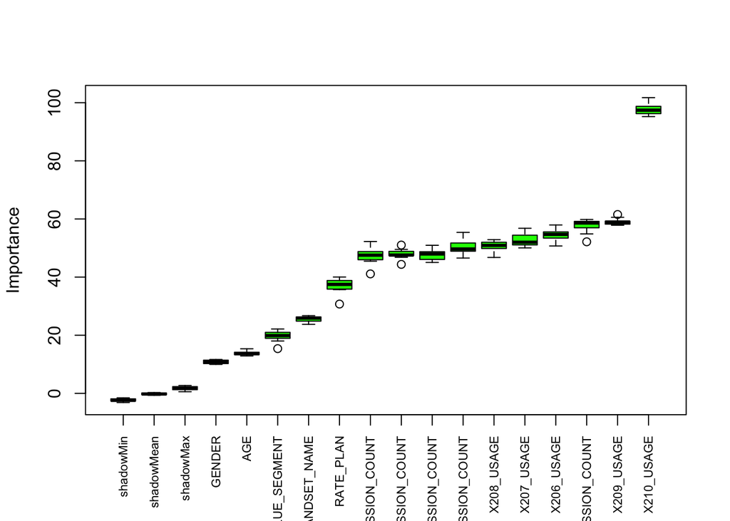

```r
plot(boruta.train, xlab = "", xaxt = "n")
lz<-lapply(1:ncol(boruta.train$ImpHistory),function(i)
boruta.train$ImpHistory[is.finite(boruta.train$ImpHistory[,i]),i])
names(lz) <- colnames(boruta.train$ImpHistory)
Labels <- sort(sapply(lz,median))
axis(side = 1,las=2,labels = names(Labels),
at = 1:ncol(boruta.train$ImpHistory), cex.axis = 0.7)
```

Applying the feature selection, It’s obvious that the “TOTAL_CONSUMPTION” and the “X210_USAGE” contributes with a high score accuracy, thus; let’s train our model against those two attributes permuting over the rest of the months usage.

We applied feature selection using Azure machine learning, below is a plot showing the importance of training features in order according to their AUC score on percentage

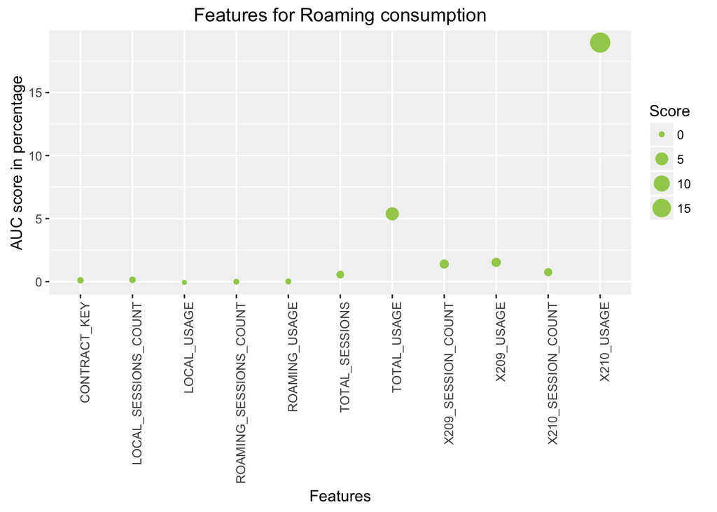

```r
features <- read.csv("featureSelectionOriginal.csv")
features$Score <- features$Score*100

ggplot(features, aes(features$Feature,features$Score,size=Score, label='')) +geom_point(colour='darkolivegreen3')  + theme(axis.text.x = element_text(angle = 90, hjust = 1)) + theme(panel.background = element_rect(fill = alpha( 'gray', 0.2))) +ggtitle("Features for Roaming consumption") + ylab("AUC score in percentage") + xlab('Features')
```

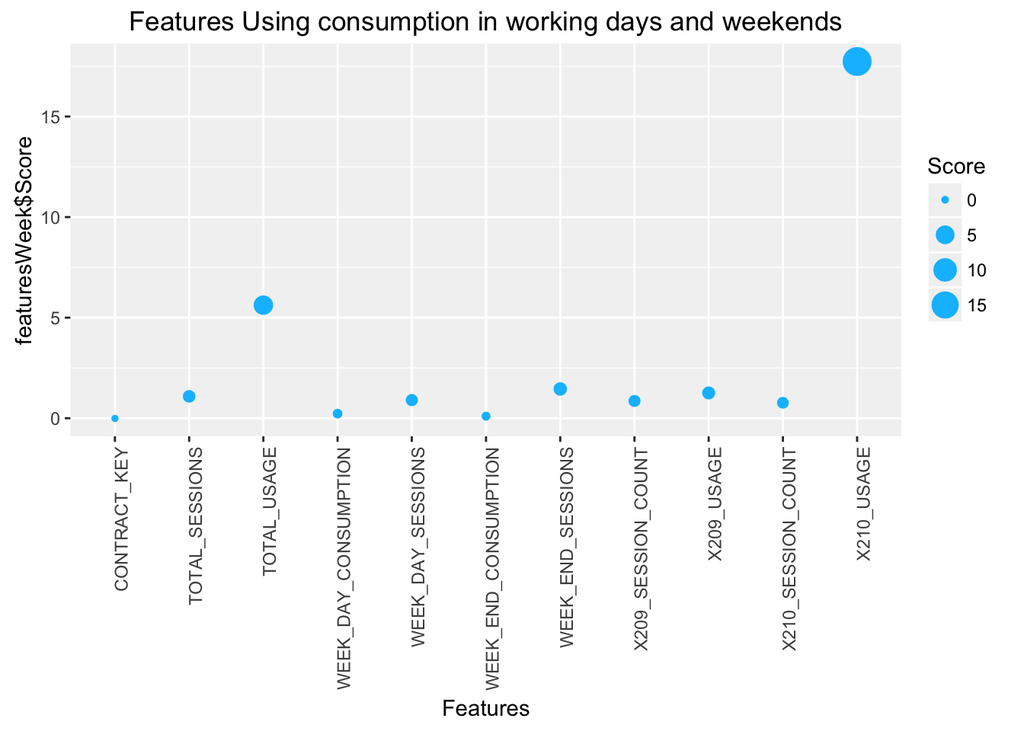

```r
featuresWeek <- read.csv("featureWeek.csv")
featuresWeek$Score <- featuresWeek$Score*100
 ggplot(featuresWeek, aes(featuresWeek$Feature,featuresWeek$Score,size=Score, label='')) +geom_point(colour='deepskyblue1')  + theme(axis.text.x = element_text(angle = 90, hjust = 1)) + theme(panel.background = element_rect(fill = alpha( 'gray', 0.2))) + xlab('Features')+ ggtitle("Features Using consumption in working days and weekends")
```

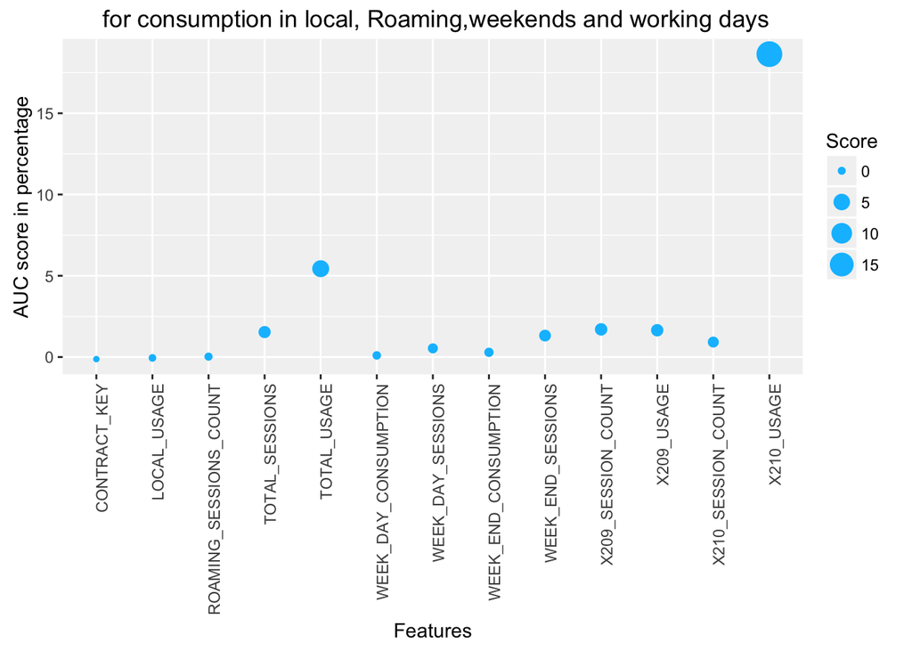

```r
featuresrw <- read.csv("featuresrw.csv")
featuresrw$Score <- featuresrw$Score*100
p <- ggplot(featuresrw, aes(featuresrw$Feature,featuresrw$Score,size=Score, label=''))
p <- p+geom_point(colour='deepskyblue1')  + theme(axis.text.x = element_text(angle = 90, hjust = 1)) + theme(panel.background = element_rect(fill = alpha( 'gray', 0.2)))
p + xlab("Features") + ylab("AUC score in percentage") + ggtitle(' for consumption in local, Roaming,weekends and working days')
```

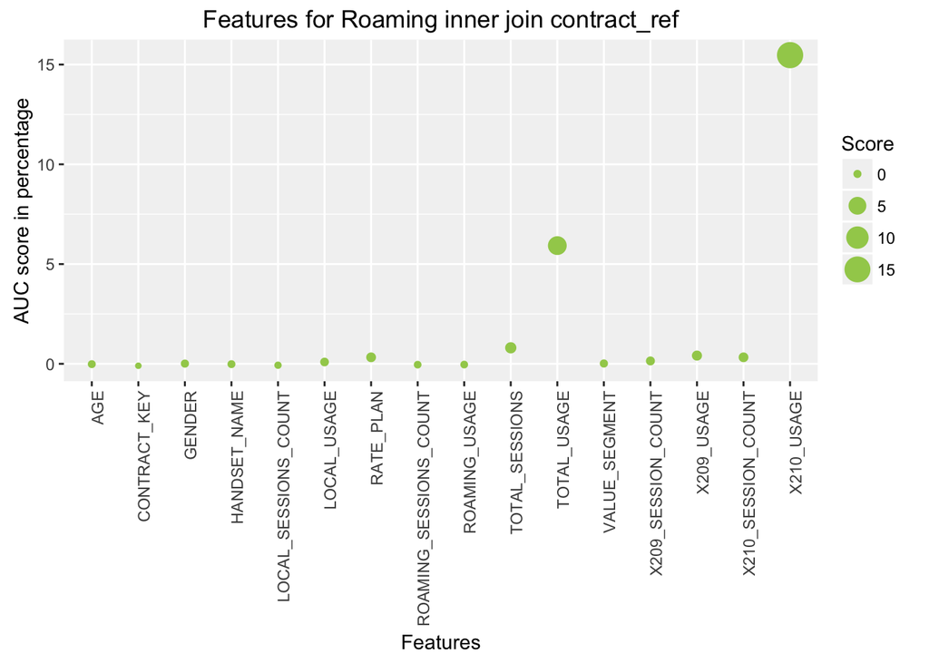

```r
featuresContract <- read.csv("featuresAll.csv")
featuresContract$Score <- featuresContract$Score*100
ggplot(featuresContract, aes(featuresContract$Feature,featuresContract$Score,size=Score, label='')) + geom_point(colour='darkolivegreen3')  + theme(axis.text.x = element_text(angle = 90, hjust = 1)) + theme(panel.background = element_rect(fill = alpha( 'gray', 0.2))) + ggtitle('Features for Roaming inner join contract_ref') + ylab("AUC score in percentage") + xlab('Features')
```

We permute over each month, and subtract three months consumption from the total consumption, excluding the consumption of the last month plus one of the other permuted month each time to produce 4 different submission files from each trained model. Below each submission file produced from a trained model and it’s accuracy.

```r
## First and Last Month
train_6_10 <- train

train_6_10  <-  cbind(TOTAL_USAGE = (train_6_10$X209_USAGE + train_6_10$X207_USAGE  +train_6_10$X208_USAGE ), train_6_10)

train_6_10 <-  cbind(TOTAL_SESSIONS = (train_6_10$X209_SESSION_COUNT + train_6_10$X207_SESSION_COUNT  +train_6_10$X208_SESSION_COUNT ), train_6_10)

train_6_10 <- dplyr::select(train_6_10, -c( X209_SESSION_COUNT, X207_SESSION_COUNT, X208_SESSION_COUNT,
                                        X209_USAGE, X207_USAGE, X208_USAGE ))

train_6_10 <- left_join(train_6_10, local_sessions_count, BY = "CONTRACT_KEY")
train_6_10 <- left_join(train_6_10, local_consumption, BY = "CONTRACT_KEY")
train_6_10 <- left_join(train_6_10, roaming_consumption, BY = "CONTRACT_KEY")
train_6_10 <- left_join(train_6_10, roaming_sessions_count, BY = "CONTRACT_KEY")
train_6_10$ROAMING_USAGE[is.na(train_6_10$ROAMING_USAGE)] = 0
train_6_10$LOCAL_USAGE[is.na(train_6_10$LOCAL_USAGE)] = 0
train_6_10$LOCAL_SESSIONS_COUNT[is.na(train_6_10$LOCAL_SESSIONS_COUNT)] = 0
train_6_10$ROAMING_SESSIONS_COUNT[is.na(train_6_10$ROAMING_SESSIONS_COUNT)] = 0
train_6_10$LOCAL_USAGE <- train_6_10$LOCAL_USAGE/(1024*1024)
train_6_10$LOCAL_USAGE <- as.integer(train_6_10$LOCAL_USAGE)
train_6_10$ROAMING_USAGE <- train_6_10$ROAMING_USAGE/(1024*1024)
train_6_10$ROAMING_USAGE <- as.integer(train_6_10$ROAMING_USAGE)

train_6_10 <- train_6_10[c(1,2,3,4,5,6,7,9,10,11,12,8)]


model <- nn(as.factor(TARGET)~. -CONTRACT_KEY, data= train_6_10)
predictedFold <- data.frame(predict(model,  train_6_10[1:11], type = "class"))
auc(as.numeric(train_6_10$TARGET), as.numeric(predictedFold$predict.model..train_6_10.1.11...type....class..))
```

```
## Area under the curve: 0.6609
```

```r
##Second and Last Month

train_7_10 <- train
train_7_10  <-  cbind(TOTAL_USAGE = (train$X209_USAGE + train$X206_USAGE  +train$X208_USAGE ), train_7_10)

train_7_10 <-  cbind(TOTAL_SESSIONS = (train$X209_SESSION_COUNT + train$X206_SESSION_COUNT  +train$X208_SESSION_COUNT ), train_7_10)

train_7_10 <- dplyr::select(train_7_10, -c( X209_SESSION_COUNT, X206_SESSION_COUNT, X208_SESSION_COUNT,
                                        X209_USAGE, X206_USAGE, X208_USAGE ))
train_7_10 <- left_join(train_7_10, local_sessions_count, BY = "CONTRACT_KEY")
train_7_10 <- left_join(train_7_10, local_consumption, BY = "CONTRACT_KEY")
train_7_10 <- left_join(train_7_10, roaming_consumption, BY = "CONTRACT_KEY")
train_7_10 <- left_join(train_7_10, roaming_sessions_count, BY = "CONTRACT_KEY")
train_7_10$ROAMING_USAGE[is.na(train_7_10$ROAMING_USAGE)] = 0
train_7_10$LOCAL_USAGE[is.na(train_7_10$LOCAL_USAGE)] = 0
train_7_10$LOCAL_SESSIONS_COUNT[is.na(train_7_10$LOCAL_SESSIONS_COUNT)] = 0
train_7_10$ROAMING_SESSIONS_COUNT[is.na(train_7_10$ROAMING_SESSIONS_COUNT)] = 0
train_7_10$LOCAL_USAGE <- train_7_10$LOCAL_USAGE/(1024*1024)
train_7_10$LOCAL_USAGE <- as.integer(train_7_10$LOCAL_USAGE)
train_7_10$ROAMING_USAGE <- train_7_10$ROAMING_USAGE/(1024*1024)
train_7_10$ROAMING_USAGE <- as.integer(train_7_10$ROAMING_USAGE)

train_7_10 <- train_7_10[c(1,2,3,4,5,6,7,9,10,11,12,8)]

model <- nn(as.factor(TARGET)~. -CONTRACT_KEY, data= train_7_10)
predictedFold <- data.frame(predict(model,  train_7_10[1:11], type = "class"))
auc(as.numeric(train_7_10$TARGET), as.numeric(predictedFold$predict.model..train_7_10.1.11...type....class..))
```

```
## Area under the curve: 0.6673
```

```r
### Accuracy of 3rd and last Month


train_8_10 <- train

train_8_10  <-  cbind(TOTAL_USAGE = (train$X209_USAGE + train$X206_USAGE  +train$X207_USAGE ), train_8_10)

train_8_10 <-  cbind(TOTAL_SESSIONS = (train$X209_SESSION_COUNT + train$X206_SESSION_COUNT  +train$X207_SESSION_COUNT ), train_8_10)

train_8_10 <- dplyr::select(train_8_10, -c( X209_SESSION_COUNT, X206_SESSION_COUNT, X207_SESSION_COUNT,
                                        X209_USAGE, X206_USAGE, X207_USAGE ))

train_8_10 <- left_join(train_8_10, local_sessions_count, BY = "CONTRACT_KEY")
train_8_10 <- left_join(train_8_10, local_consumption, BY = "CONTRACT_KEY")
train_8_10 <- left_join(train_8_10, roaming_consumption, BY = "CONTRACT_KEY")
train_8_10 <- left_join(train_8_10, roaming_sessions_count, BY = "CONTRACT_KEY")
train_8_10$ROAMING_USAGE[is.na(train_8_10$ROAMING_USAGE)] = 0
train_8_10$LOCAL_USAGE[is.na(train_8_10$LOCAL_USAGE)] = 0
train_8_10$LOCAL_SESSIONS_COUNT[is.na(train_8_10$LOCAL_SESSIONS_COUNT)] = 0
train_8_10$ROAMING_SESSIONS_COUNT[is.na(train_8_10$ROAMING_SESSIONS_COUNT)] = 0
train_8_10$LOCAL_USAGE <- train_8_10$LOCAL_USAGE/(1024*1024)
train_8_10$LOCAL_USAGE <- as.integer(train_8_10$LOCAL_USAGE)
train_8_10$ROAMING_USAGE <- train_8_10$ROAMING_USAGE/(1024*1024)
train_8_10$ROAMING_USAGE <- as.integer(train_8_10$ROAMING_USAGE)

train_8_10 <- train_8_10[c(1,2,3,4,5,6,7,9,10,11,12,8)]


model <- nn(as.factor(TARGET)~. -CONTRACT_KEY, data= train_8_10)
predictedFold <- data.frame(predict(model,  train_8_10[1:11], type = "class"))
auc(as.numeric(train_8_10$TARGET), as.numeric(predictedFold$predict.model..train_8_10.1.11...type....class..))
```

```
## Area under the curve: 0.6713
```

[output not shown]

### Model ensembling:

Where we created ensembles from all the previous submission files, using the “Kaggle_avg.py” script [link](https://github.com/MLWave/Kaggle-Ensemble-Guide/blob/master/kaggle_avg.py).

The following JavaScript chart shows how each submission file contributed in our final submission.

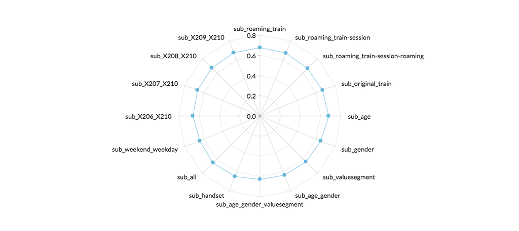